# Filter Cutoff Investigation

C. Savonen, CCDL for ALSF

Created: 3/6/2019

#### Purpose: Set up the tabula muris 10X dataset we are working with for normalization and subsequent steps.

Subgoal: The cutoffs used for the smart-seq2 single cell data do not work well on the 10X single cell data. This is not surprising, but let’s investigate the 10X tab mur data so we can come up with some better cutoffs.

Other note: For the purposes of saving room and making a more manageable dataset to work with, I am only using P4, and have excluded the Liver and spleen samples.

```r
# Load ggplot2 library
library(ggplot2)
# magrittr pipe
`%>%` <- dplyr::`%>%`
```

Set up the data

```r
# Read in data
all.data <- readRDS(file.path("tab_mur_data", "counts_tab_mur.RDS"))
# Keep the gene names separate
gene.names <- all.data$genes
# Get rid of gene column
all.data <- all.data[, -1]
# Remove Liver samples
all.data <- all.data %>% dplyr::select(-dplyr::contains("10X_P4_2"))
```

Make cell info dataframe for labeling purposes

```r
# Clean up sample names
#colnames(all.data) <- gsub("_possorted_genome.bam", "", #colnames(all.data))
# Make a dataframe of this cell info
cell.info <- data.frame(strsplit(colnames(all.data), "\\.")) %>%
  t()
# Change column names
colnames(cell.info) <- c("cell_barcode", "sample.id")
# Keep the full id names for each as well for matching purposes
cell.info <- data.frame(full.id = colnames(all.data), cell.info)
```

Read in the metadata file obtained from figshare, clean it up so we can merge it with the sample names obtained in the cell.info dataframe.

```r
# Import metadata file and make it with only the variables and samples we want
metadata <- readr::read_csv(file.path("tab_mur_data", "metadata_droplet.csv")) %>%
  dplyr::select("channel", "mouse.id", "tissue") %>%
  dplyr::filter(grepl("10X_P4", channel), tissue != "Liver", tissue != "Spleen")
# Make column name matching so we can use inner_join to merge the info
colnames(metadata)[1] <- "sample.id"
```

The liver samples had 95% of their data dropped in Alevin due to noisy cell barcodes. Spleen is excluded because then it became the only tissue that wasn’t represented in both mice.

```r
# Merge these two frames together
metadata <- dplyr::inner_join(cell.info, metadata, by = "sample.id") %>%
  readr::write_tsv("metadata.tsv")
```

```
Column `sample.id` joining factor and character vector, coercing into character vector
```

```r
# Double check that metadata and data match
all.equal(metadata$full.id, colnames(all.data))
```

```
[1] TRUE
```

Let’s look at total counts for these samples

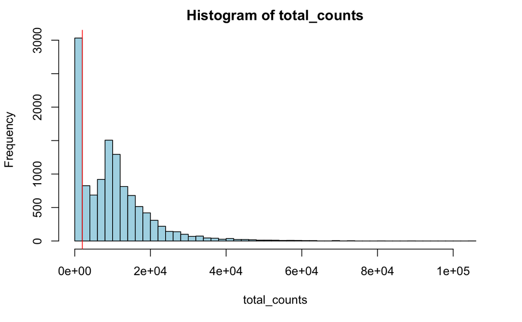

```r
# Calculate the total number of counts for each sample
total_counts <- apply(all.data, 2, sum)
# Histogram of this data
hist(total_counts, breaks = 50, col = "lightblue");
abline(v = 2000, col = "red")
```

```r
# Let's look at summary statistics
summary(total_counts)
```

```
   Min. 1st Qu.  Median    Mean 3rd Qu.    Max.
      1    1965    8835    9902   13896  104659
```

Filter out samples based on total counts.

```r
# Filter out these samples from data and metadata
filtered_data <- all.data[, which(total_counts > 2000)]
filtered_metadata <- metadata[which(total_counts > 2000), ]
# Double check everything matches
all.equal(colnames(filtered_data), filtered_metadata$full.id)
```

```
[1] TRUE
```

Make a data matrix for ease of collecting stats

```r
data.mat <- filtered_data %>% as.matrix()
```

For least stringent filter, let’s determine what the smallest expression value is

```r
# Determine a detection cutoff
min.cutoff <- min(data.mat[which(data.mat != 0)])
```

Let’s make a detection matrix to just hold each data point as expressed or not

```r
# Make a matrix of detected or not detected logical values
boolean <- data.mat >= min.cutoff
```

Determine cutoff for how many samples should express a gene

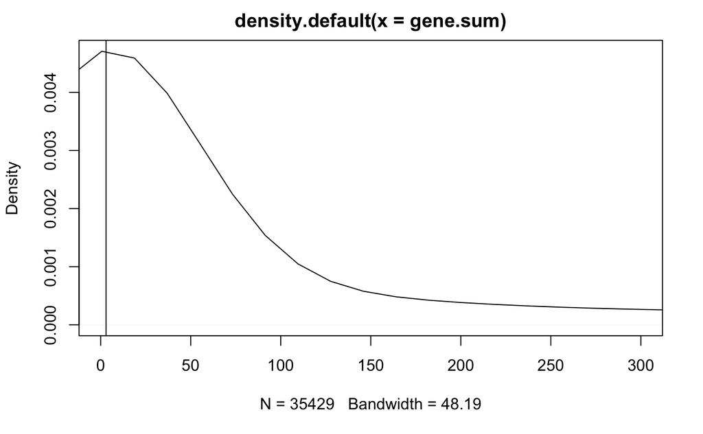

```r
# Make a vector that has the number of samples that express a gene
gene.sum <- apply(boolean, 1, sum)
# Plot this information
plot(density(gene.sum), xlim = c(0, 300));
abline(v = 3)
```

Determine cutoff for how many genes should be expressed in a sample

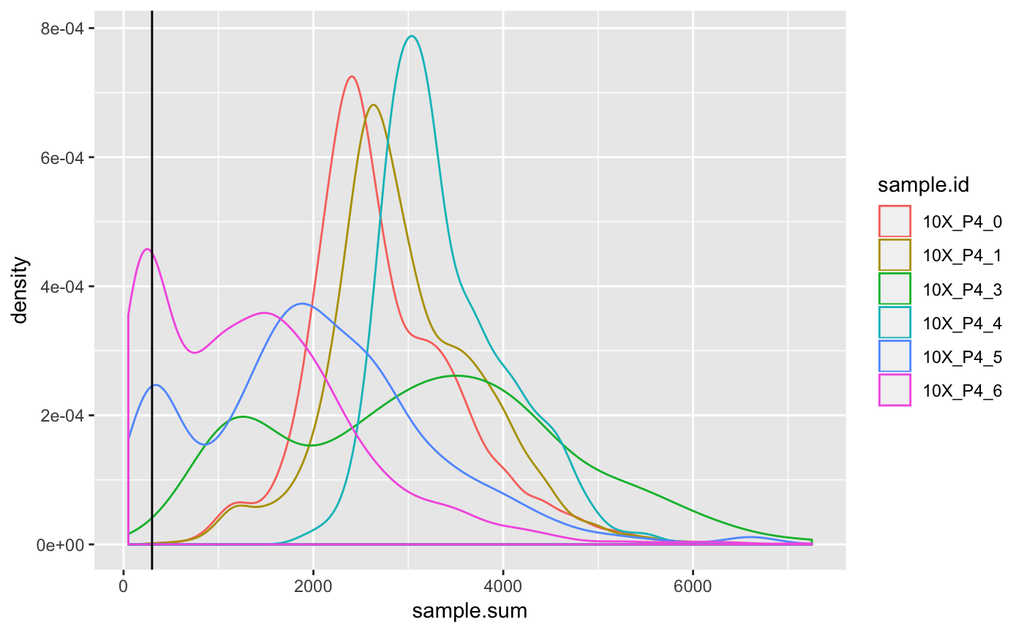

```r
# Make vector that has the number of genes expressed by each cell
sample.sum <- apply(boolean, 2, sum)
# Put this with the cell.info so we can look at the distributions by samples
sample.sum.df <- data.frame(sample.sum, filtered_metadata)
# Plot with each sample as its own line
ggplot(sample.sum.df, aes(x = sample.sum, color = sample.id)) +
  geom_density() +
  geom_vline(aes(xintercept = 300))
```

Use cutoffs determined by looking at the plots above and filter the data matrix, tack on gene names, write to tsv file.

```r
# Apply these filters to the data and save as filtered_data
filtered_data <- filtered_data[, which(sample.sum > 300)] %>%
  dplyr::filter(gene.sum > 10)
# Add the genes column to the front
filtered_data <- data.frame("genes" = gene.names[which(gene.sum > 10)],
                            filtered_data)
# Let's check out how much genes x samples we have
dim(filtered_data)
```

```
[1] 17957  8693
```

Assuming what we have is good amount, let’s filter the metadata to be the same and check out what that leaves us with.

```r
# Filter the metadata based on what's left in the filtered_dataset
filtered_metadata <- metadata %>%
  dplyr::filter(full.id %in% colnames(filtered_data)) %>%
  dplyr::mutate_all(as.factor)
# Let's check out what this looks like
summary(filtered_metadata)
```

```
                      full.id               cell_barcode
 AAACCTGAGAGTACAT.10X_P4_1:   1   AAGTCTGGTACCTACA:   2
 AAACCTGAGATGCCAG.10X_P4_5:   1   ACGAGCCAGACTAGAT:   2
 AAACCTGAGATTACCC.10X_P4_0:   1   ACTGAGTTCCGATATG:   2
 AAACCTGAGTGCCAGA.10X_P4_0:   1   ACTGATGTCACGACTA:   2
 AAACCTGCAAATCCGT.10X_P4_0:   1   AGAATAGAGAAACGCC:   2
 AAACCTGCAAGGCTCC.10X_P4_5:   1   ATCTACTTCTCCGGTT:   2
 (Other)                  :8686   (Other)         :8680
    sample.id     mouse.id        tissue
 10X_P4_0:3292   3-M-8:4048   Bladder:1212
 10X_P4_1:2632   3-M-9:4644   Kidney :1556
 10X_P4_3: 183                Tongue :5924
 10X_P4_4:1029
 10X_P4_5: 573
 10X_P4_6: 983
```

Let’s save things to tsv files

```r
# Save the metadata
readr::write_tsv(filtered_metadata, file.path("tab_mur_data", "filtered_metadata_tab_mur.tsv"))
# Save the data
#readr::write_tsv(filtered_data, file.path("tab_mur_data", "filtered_counts_tab_mur.tsv"))
saveRDS(filtered_data, file.path("tab_mur_data", "filtered_counts_tab_mur.RDS"))
```